# CWRU DSCI351-351M-453: Week11b-p-Simple-LinRegrAlgorithm-LPAwR

2008-351-351m-451-w11b-p-LinRegrAlgo-LPAwR

Profs: R. H. French, L. S. Bruckman, P. Leu, K. Davis, S. Cirlos

10 November, 2022

#### Understanding simple linear regression

##### Build and use our own simple linear regression algorithm

- Create multiple linear regression models in R
- Perform diagnostic tests of such models
- Score new data using a linear regression model
- Examine how well the model predicts the new data

Regression seeks to obtain the model coefficients

- that explain the variable’s relationship the best
- but such a model only seldom reflects the relationship entirely

Indeed, measurement error,

- And also attributes that are not included in the analysis
  - affect also the data.

The model residuals

- express the deviation of the observed data points
  - to the model.

The residual’s value

- is the vertical distance from a point
  - to the regression line.

#### Let’s examine this with an example of the Fisher’s/Anderson’s iris dataset.

- We have already seen that the dataset contains data about iris flowers.

For the purpose of this example,

- we will consider the petal length as the response
  - sometimes the response is referred to as the “criterion”
- and the petal width as the predictor

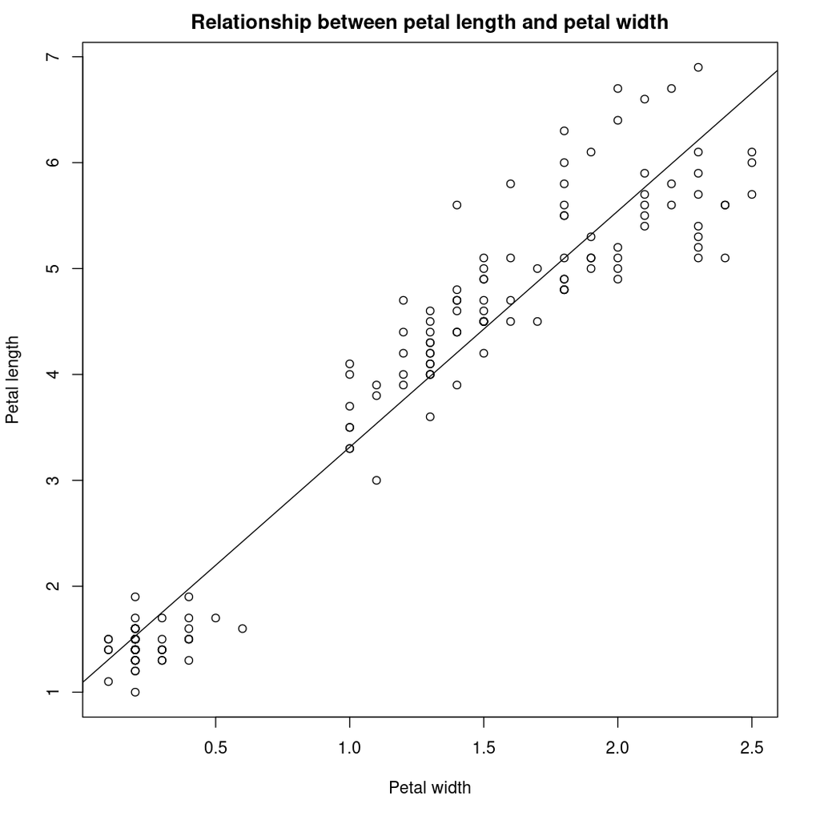

```r
plot(
  iris$Petal.Length ~ iris$Petal.Width,
  main = "Relationship between petal length and petal width",
  xlab = "Petal width",
  ylab = "Petal length"
)
iris.lm = lm(iris$Petal.Length ~ iris$Petal.Width)
abline(iris.lm)
```

##### Computing the intercept and slope coefficient

```r
SlopeCoef = cor(iris$Petal.Length, iris$Petal.Width) *
  (sd(iris$Petal.Length) / sd(iris$Petal.Width))
SlopeCoef
```

```
[1] 2.22994
```

```r
coeffs = function(y, x) {
  ((length(y) * sum(y * x)) -
     (sum(y) * sum(x)))  /
    (length(y) * sum(x ^ 2) - sum(x) ^ 2)
}

coeffs(iris$Petal.Length, iris$Petal.Width)
```

```
[1] 2.22994
```